# 教師あり学習 課題

谷口友哉

# 課題2

R パッケージ “MASS”の “Boston” データセットに対して，変数 medv を目的変数，それ以外を説明変数として lasso を適用し，解パス図および CV の推移の図， CV によって選択された回帰係数を出力せよ

```r
data(Boston)
head(Boston)
```

```
##      crim zn indus chas   nox    rm  age    dis rad tax ptratio  black lstat
## 1 0.00632 18  2.31    0 0.538 6.575 65.2 4.0900   1 296    15.3 396.90  4.98
## 2 0.02731  0  7.07    0 0.469 6.421 78.9 4.9671   2 242    17.8 396.90  9.14
## 3 0.02729  0  7.07    0 0.469 7.185 61.1 4.9671   2 242    17.8 392.83  4.03
## 4 0.03237  0  2.18    0 0.458 6.998 45.8 6.0622   3 222    18.7 394.63  2.94
## 5 0.06905  0  2.18    0 0.458 7.147 54.2 6.0622   3 222    18.7 396.90  5.33
## 6 0.02985  0  2.18    0 0.458 6.430 58.7 6.0622   3 222    18.7 394.12  5.21
##   medv
## 1 24.0
## 2 21.6
## 3 34.7
## 4 33.4
## 5 36.2
## 6 28.7
```

- glmnetUtils パッケージ を使うことで formula チック (y ~ x) で書ける
  - https://cran.r-project.org/web/packages/glmnetUtils/vignettes/intro.html

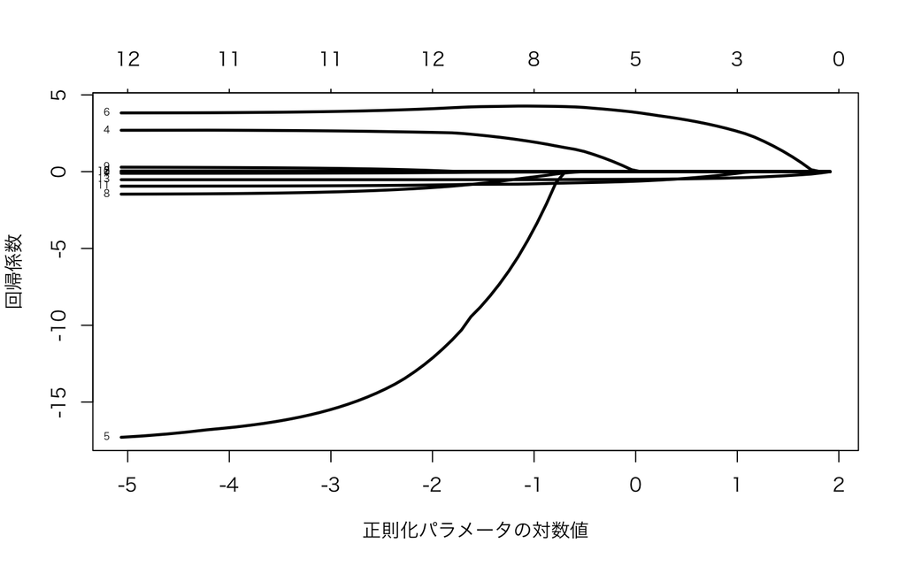

```r
par(family= "HiraKakuProN-W3")
fit.Lasso <- glmnet(medv ~ ., data = Boston)
plot(fit.Lasso, xvar="lambda", label=TRUE,
     xlab="正則化パラメータの対数値",
     ylab="回帰係数", col="black", lwd=2.5)
```

- ggfortify パッケージを使うことで、ggplot 風に描画できる
  - https://cran.r-project.org/web/packages/ggfortify/vignettes/plot_lm.html

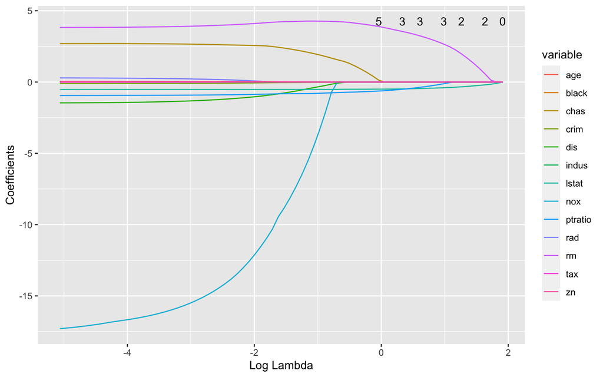

```r
autoplot(fit.Lasso, xvar = "lambda")
```

- CV

```r
fit.Lasso.cv <- cv.glmnet(medv ~ ., data = Boston,
                           nfolds = 10,
                           alpha = 1,
                           standardize = TRUE)
```

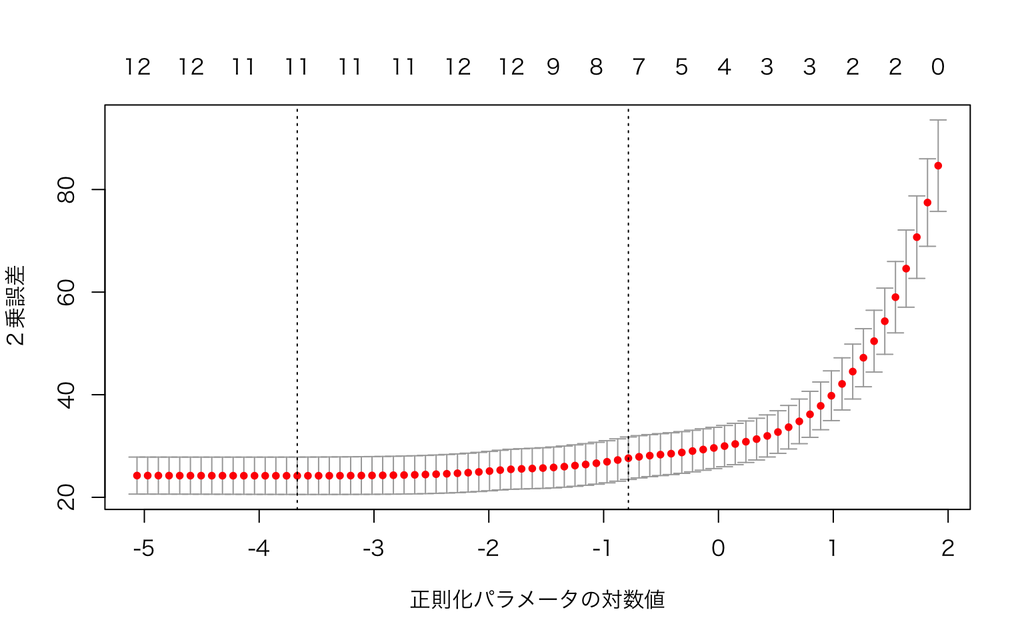

```r
par(family= "HiraKakuProN-W3")
# CV値の推移をプロット
plot(fit.Lasso.cv, xlab="正則化パラメータの対数値", ylab="２乗誤差")
```

```r
# CV値が最小となる正則化パラメータ値を出力
fit.Lasso.cv$lambda.min
```

```
## [1] 0.02551743
```

```r
# 1標準誤差ルールにより選択された正則化パラメータの値を出力
fit.Lasso.cv$lambda.1se
```

```
## [1] 0.4564174
```